# Valószínűségszámítás alapok

## A matematikai statisztika Önök szerint

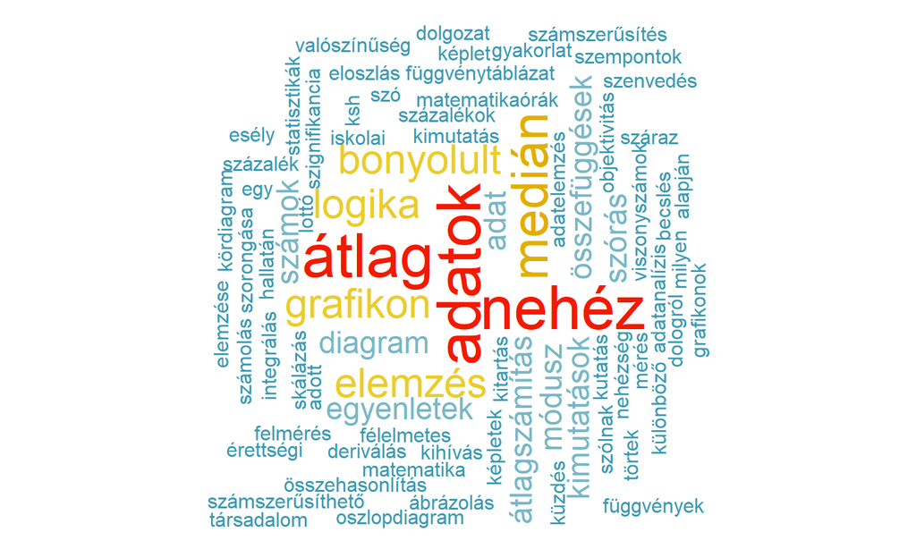

## Mennyire értékelik a matektudásukat?

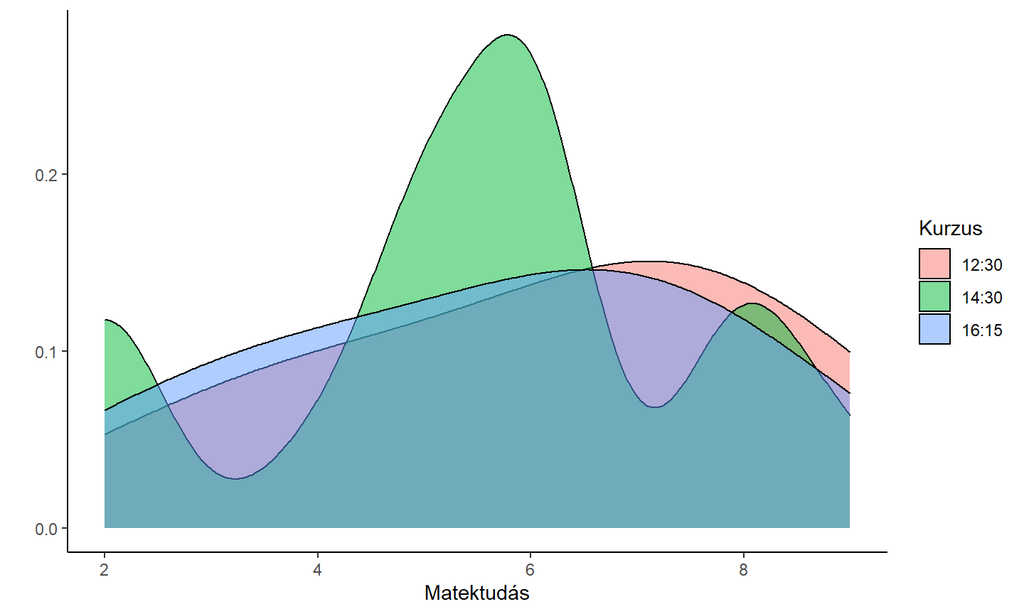

## Remélt eredmény

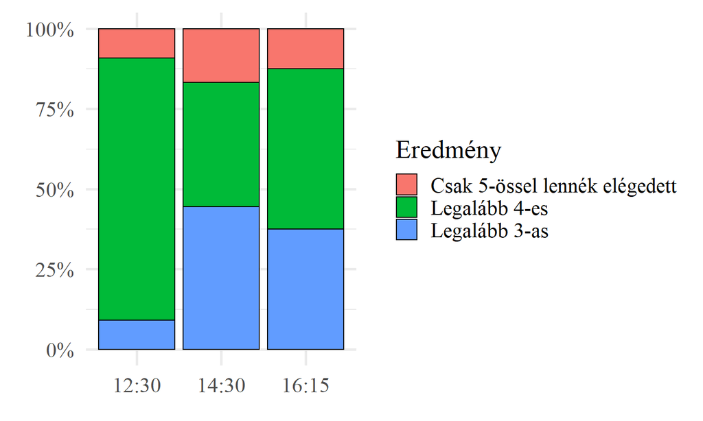

## A félévről

**Trigger warning:** Sokat fogunk számolni ⇒ számológépre szükség lesz

Félév felépítése:

1. negyedév: Valószínűségszámítás - **ZH: 03.23.**
2. negyedév: Matematikai statisztika alapjai - **ZH: 05.18.**  
   Leíró + becsléselmélet + hipotézisvizsgálat

Végeredmény: pontösszeg alapján  
Házi feladatok  
Órai jelenlét és hiányzás

## Valószínűségszámítás

- **Kísérlet**: amit végzünk, megfigyelünk, stb.
- **Esemény**: a kísérlet kimenetele, ami ténylegesen megtörténhet
- **Valószínűség**: az eseményhez rendeljük, ha ismételten elvégeznénk a kísérletet, várhatóan az esetek hány százalékában következik be az esemény
- **Biztos és lehetetlen esemény**
- **Elemi és összetett esemény**
- **Klasszikus valószínűségi mező**

## Klasszikus valószínűségi mező

Ha az összes elemi esemény valószínűsége egyenlő, akkor bármilyen összetett esemény valószínűsége:

\[P(A)=\frac{\textit{kedvező elemi események száma}}{\textit{összes elemi esemény száma}}\]

## Klasszikus valószínűségi mező

1. 32 lapos magyarkártya-pakliból húzunk. Mennyi a valószínűsége annak, hogy a húzott kártya piros?
2. Szabályos dobókockával dobunk. Mennyi annak a valószínűsége, hogy a dobott szám nagyobb, vagy egyenlő 5-tel?
3. Feldobunk két pénzérmét. Mennyi a valószínűsége, hogy mindkét dobás fej?
4. Öten mehetnek kenuzni. Mennyi a valószínűsége, hogy ha kilenc barátunkkal sorsolással döntjük el, ki mehet, a szerencsések között leszünk mi is?
5. Véletlenszámgenerátorral négyjegyű PIN-kódot generálunk. Mennyi a valószínűsége, hogy a kapott számban nem ismétlődnek a számjegyek?

## Kombinatorika

Alapfelállás: vannak elemeink, és azokkal szeretnénk valamit:

Mit is?

## Kombinatorika

Alapfelállás: vannak elemeink, és azokkal szeretnénk valamit:

1. Sorbarakni mindet
2. Sorbarakni néhányat
3. Kiválasztani néhányat

## Kombinatorika

Alapfelállás: vannak elemeink, és azokkal szeretnénk valamit:

1. Sorbarakni mindet ⇒ **Permutáció**
2. Sorbarakni néhányat ⇒ **Variáció**
3. Kiválasztani néhányat ⇒ **Kombináció**

Mindháromnak van ismétlés nélküli és ismétléses változata

## Permutáció

Adott *n* darab elem, és azt vizsgáljuk, ezeket hányféleképpen tudjuk sorbaállítani.

Mondjanak példát

- ismétlés nélküli és
- ismétléses permutációra!

## Permutáció

Képletek:

\[P_n = n!\] \[n! = n*(n-1)*...*2*1\] \[P_{n}^{(k_1, k_2, ...k_r)}=\frac{n!}{k_1!*k_2!*...*k_r!}\]

Fontos információ: \(0!=1\)

## Variáció

Adott *n* darab elem, és azt vizsgáljuk, ezekből hányféleképpen tudunk sorbaállítani *k* darabot.

Mondjanak példát

- ismétlés nélküli és
- ismétléses variációra!

## Variáció

Képletek:

\[V_n^k=\frac{n!}{(n-k)!}\] \[V_n^{i,k}=n^k\]

## Kombináció

Adott *n* darab elem, és azt vizsgáljuk, hányféleképpen tudunk ezekből kiválasztani *k* darabot. A sorrend nem számít.

Mondjanak példát

- ismétlés nélküli és
- ismétléses kombinációra

## Kombináció

Képletek:

\[C_n^k=\binom{n}{k}=\frac{n!}{k!*(n-k)!}\] \[C_n^{i, k}=\binom{n+k-1}{k}\]

Megjegyzés: Az \(\binom{n}{k}\)-t úgy mondjuk: "n alatt a k"

## Vissza a valószínűségekhez

Általában az összes esetet viszonylag könnyebb kiszámolni, a kedvező esetek kiszámításában pedig előfordulnak csavarok.

Nézzünk néhány további feladatot!